# MACD Test Optimisation - Final

## Import Libraries

```python
import plotly.io as pio
pio.renderers.default = 'iframe'
```

```python
import pandas as pd
import pandas_ta as ta
import numpy as np
import yfinance as yf
import vectorbt as vbt
import datetime

import seaborn as sns
import mplfinance as mpf
```

## Get Data

```python
price_df = yf.Ticker('BTC-USD').history(start=datetime.datetime(2015, 1, 1),
                                        end=datetime.datetime(2022, 9, 20),
                                        interval = '1D')
```

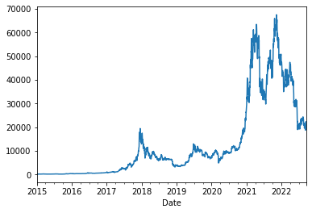

```python
price_df['Close'].plot()
```

## Indicator Calculation

```python
help(ta.macd)
```

```
Help on function macd in module pandas_ta.momentum.macd:

macd(close, fast=None, slow=None, signal=None, talib=None, offset=None, **kwargs)
    Moving Average Convergence Divergence (MACD)

    The MACD is a popular indicator to that is used to identify a security's trend.
    While APO and MACD are the same calculation, MACD also returns two more series
    called Signal and Histogram. The Signal is an EMA of MACD and the Histogram is
    the difference of MACD and Signal.

    Sources:
        https://www.tradingview.com/wiki/MACD_(Moving_Average_Convergence/Divergence)
        AS Mode: https://tr.tradingview.com/script/YFlKXHnP/

    Calculation:
        Default Inputs:
            fast=12, slow=26, signal=9
        EMA = Exponential Moving Average
        MACD = EMA(close, fast) - EMA(close, slow)
        Signal = EMA(MACD, signal)
        Histogram = MACD - Signal

        if asmode:
            MACD = MACD - Signal
            Signal = EMA(MACD, signal)
            Histogram = MACD - Signal

    Args:
        close (pd.Series): Series of 'close's
        fast (int): The short period. Default: 12
        slow (int): The long period. Default: 26
        signal (int): The signal period. Default: 9
        talib (bool): If TA Lib is installed and talib is True, Returns the TA Lib
            version. Default: True
        offset (int): How many periods to offset the result. Default: 0

    Kwargs:
        asmode (value, optional): When True, enables AS version of MACD.
            Default: False
        fillna (value, optional): pd.DataFrame.fillna(value)
        fill_method (value, optional): Type of fill method

    Returns:
        pd.DataFrame: macd, histogram, signal columns.
```

```python
macd = ta.macd(price_df['Close'])
```

```python
macd
```

| Date | MACD_12_26_9 | MACDh_12_26_9 | MACDs_12_26_9 |
| --- | --- | --- | --- |
| 2015-01-01 | NaN | NaN | NaN |
| 2015-01-02 | NaN | NaN | NaN |
| 2015-01-03 | NaN | NaN | NaN |
| 2015-01-04 | NaN | NaN | NaN |
| 2015-01-05 | NaN | NaN | NaN |
| ... | ... | ... | ... |
| 2022-09-16 | -305.970901 | 53.829593 | -359.800494 |
| 2022-09-17 | -305.678956 | 43.297231 | -348.976186 |
| 2022-09-18 | -358.450945 | -7.579807 | -350.871138 |
| 2022-09-19 | -385.770169 | -27.919225 | -357.850944 |
| 2022-09-20 | -454.896157 | -77.636170 | -377.259987 |

2820 rows × 3 columns

```python
nplot = -300
```

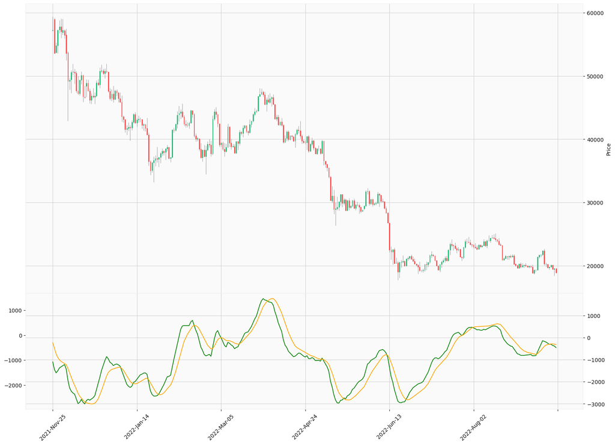

```python
all_plot = [
            mpf.make_addplot(macd['MACD_12_26_9'].iloc[nplot:], panel=1, color='green'),
            mpf.make_addplot(macd['MACDs_12_26_9'].iloc[nplot:], panel=1, color='orange'),
            ]

price_df.index = pd.to_datetime(price_df.index)

price_plot = mpf.plot(price_df.iloc[nplot:], type='candle', style='yahoo', addplot=all_plot, figsize=(20, 15))
```

## Strategy

### Strategy พื้นฐาน

```python
strategy_df = price_df.copy()
```

```python
strategy_df
```

| Date | Open | High | Low | Close | Volume | Dividends | Stock Splits |
| --- | --- | --- | --- | --- | --- | --- | --- |
| 2015-01-01 | 320.434998 | 320.434998 | 314.002991 | 314.248993 | 8036550 | 0 | 0 |
| 2015-01-02 | 314.079010 | 315.838989 | 313.565002 | 315.032013 | 7860650 | 0 | 0 |
| 2015-01-03 | 314.846008 | 315.149994 | 281.082001 | 281.082001 | 33054400 | 0 | 0 |
| 2015-01-04 | 281.145996 | 287.230011 | 257.612000 | 264.195007 | 55629100 | 0 | 0 |
| 2015-01-05 | 265.084015 | 278.341003 | 265.084015 | 274.473999 | 43962800 | 0 | 0 |
| ... | ... | ... | ... | ... | ... | ... | ... |
| 2022-09-16 | 19704.005859 | 19870.628906 | 19400.076172 | 19772.583984 | 30123362273 | 0 | 0 |
| 2022-09-17 | 19777.033203 | 20162.531250 | 19777.033203 | 20127.576172 | 24957448100 | 0 | 0 |
| 2022-09-18 | 20127.234375 | 20127.234375 | 19387.492188 | 19419.505859 | 31254779144 | 0 | 0 |
| 2022-09-19 | 19418.572266 | 19639.480469 | 18390.318359 | 19544.128906 | 40177002624 | 0 | 0 |
| 2022-09-20 | 19545.591797 | 19602.457031 | 18813.455078 | 18890.789062 | 36791346508 | 0 | 0 |

2820 rows × 7 columns

```python
macd
```

| Date | MACD_12_26_9 | MACDh_12_26_9 | MACDs_12_26_9 |
| --- | --- | --- | --- |
| 2015-01-01 | NaN | NaN | NaN |
| 2015-01-02 | NaN | NaN | NaN |
| 2015-01-03 | NaN | NaN | NaN |
| 2015-01-04 | NaN | NaN | NaN |
| 2015-01-05 | NaN | NaN | NaN |
| ... | ... | ... | ... |
| 2022-09-16 | -305.970901 | 53.829593 | -359.800494 |
| 2022-09-17 | -305.678956 | 43.297231 | -348.976186 |
| 2022-09-18 | -358.450945 | -7.579807 | -350.871138 |
| 2022-09-19 | -385.770169 | -27.919225 | -357.850944 |
| 2022-09-20 | -454.896157 | -77.636170 | -377.259987 |

2820 rows × 3 columns

```python
strategy_df['long_signal'] = macd.apply(lambda _: _['MACD_12_26_9'] > _['MACDs_12_26_9'], axis=1)
```

```python
strategy_df['short_signal'] = macd.apply(lambda _: _['MACD_12_26_9'] < _['MACDs_12_26_9'], axis=1)
```

```python
strategy_df
```

| Date | Open | High | Low | Close | Volume | Dividends | Stock Splits | long_signal | short_signal |
| --- | --- | --- | --- | --- | --- | --- | --- | --- | --- |
| 2015-01-01 | 320.434998 | 320.434998 | 314.002991 | 314.248993 | 8036550 | 0 | 0 | False | False |
| 2015-01-02 | 314.079010 | 315.838989 | 313.565002 | 315.032013 | 7860650 | 0 | 0 | False | False |
| 2015-01-03 | 314.846008 | 315.149994 | 281.082001 | 281.082001 | 33054400 | 0 | 0 | False | False |
| 2015-01-04 | 281.145996 | 287.230011 | 257.612000 | 264.195007 | 55629100 | 0 | 0 | False | False |
| 2015-01-05 | 265.084015 | 278.341003 | 265.084015 | 274.473999 | 43962800 | 0 | 0 | False | False |
| ... | ... | ... | ... | ... | ... | ... | ... | ... | ... |
| 2022-09-16 | 19704.005859 | 19870.628906 | 19400.076172 | 19772.583984 | 30123362273 | 0 | 0 | True | False |
| 2022-09-17 | 19777.033203 | 20162.531250 | 19777.033203 | 20127.576172 | 24957448100 | 0 | 0 | True | False |
| 2022-09-18 | 20127.234375 | 20127.234375 | 19387.492188 | 19419.505859 | 31254779144 | 0 | 0 | False | True |
| 2022-09-19 | 19418.572266 | 19639.480469 | 18390.318359 | 19544.128906 | 40177002624 | 0 | 0 | False | True |
| 2022-09-20 | 19545.591797 | 19602.457031 | 18813.455078 | 18890.789062 | 36791346508 | 0 | 0 | False | True |

2820 rows × 9 columns

```python
long_signal_df = strategy_df.ta.tsignals(strategy_df['long_signal'], asbool=True, append=True)
```

```python
short_signal_df = strategy_df.ta.tsignals(strategy_df['short_signal'], asbool=True, append=True)
```

```python
long_signal_df['long_entry'] = long_signal_df['TS_Entries'].shift(1).fillna(False)
```

```python
short_signal_df['short_entry'] = short_signal_df['TS_Entries'].shift(1).fillna(False)
```

## Backtesting

### Strategy พื้นฐาน

```python
port = vbt.Portfolio.from_signals(strategy_df['Open'],
                                 entries=long_signal_df['long_entry'], # Long Entry
                                 exits=short_signal_df['short_entry'],
                                 freq='D'# Long Exit
                                 )
```

```python
port.stats()
```

```
Start                                2015-01-01 00:00:00
End                                  2022-09-20 00:00:00
Period                                2820 days 00:00:00
Start Value                                        100.0
End Value                                   20852.248116
Total Return [%]                            20752.248116
Benchmark Return [%]                         5999.705696
Max Gross Exposure [%]                             100.0
Total Fees Paid                                      0.0
Max Drawdown [%]                               46.411072
Max Drawdown Duration                  575 days 00:00:00
Total Trades                                          87
Total Closed Trades                                   87
Total Open Trades                                      0
Open Trade PnL                                       0.0
Win Rate [%]                                   47.126437
Best Trade [%]                                116.213413
Worst Trade [%]                               -17.491119
Avg Winning Trade [%]                          24.347947
Avg Losing Trade [%]                           -6.043972
Avg Winning Trade Duration    27 days 12:17:33.658536585
Avg Losing Trade Duration      8 days 05:44:20.869565217
Profit Factor                                   1.532456
Expectancy                                    238.531588
Sharpe Ratio                                     1.62813
Calmar Ratio                                    2.146173
Omega Ratio                                     1.415568
Sortino Ratio                                   2.671499
dtype: object
```

```python
port.plot().show()
```

[interactive chart not shown]

```python
port = vbt.Portfolio.from_signals(strategy_df['Open'],
                                 short_entries=short_signal_df['short_entry'],
                                 short_exits=long_signal_df['long_entry'],
                                freq='D'
                                 )
```

```python
port.stats()
```

```
Start                                2015-01-01 00:00:00
End                                  2022-09-20 00:00:00
Period                                2820 days 00:00:00
Start Value                                        100.0
End Value                                      68.181887
Total Return [%]                              -31.818113
Benchmark Return [%]                         5999.705696
Max Gross Exposure [%]                             100.0
Total Fees Paid                                      0.0
Max Drawdown [%]                               72.901168
Max Drawdown Duration                 2389 days 00:00:00
Total Trades                                          87
Total Closed Trades                                   86
Total Open Trades                                      1
Open Trade PnL                                 -0.448924
Win Rate [%]                                   36.046512
Best Trade [%]                                 37.451252
Worst Trade [%]                               -24.218598
Avg Winning Trade [%]                          12.918468
Avg Losing Trade [%]                           -6.899608
Avg Winning Trade Duration    23 days 03:05:48.387096774
Avg Losing Trade Duration     10 days 04:21:49.090909090
Profit Factor                                   0.898598
Expectancy                                     -0.364758
Sharpe Ratio                                    0.117378
Calmar Ratio                                    -0.06634
Omega Ratio                                     1.027851
Sortino Ratio                                   0.178161
dtype: object
```

```python
port.plot().show()
```

[interactive chart not shown]

```python
port = vbt.Portfolio.from_signals(strategy_df['Open'],
                                 entries=long_signal_df['long_entry'],
                                 exits=short_signal_df['short_entry'],
                                 short_entries=short_signal_df['short_entry'], # Long Entry
                                 short_exits=long_signal_df['long_entry'],
                                 freq='D'
                                 )
```

```python
port.stats()
```

```
Start                               2015-01-01 00:00:00
End                                 2022-09-20 00:00:00
Period                               2820 days 00:00:00
Start Value                                       100.0
End Value                                  14217.456338
Total Return [%]                           14117.456338
Benchmark Return [%]                        5999.705696
Max Gross Exposure [%]                            100.0
Total Fees Paid                                     0.0
Max Drawdown [%]                               54.52742
Max Drawdown Duration                 575 days 00:00:00
Total Trades                                        174
Total Closed Trades                                 173
Total Open Trades                                     1
Open Trade PnL                               -93.610642
Win Rate [%]                                  41.618497
Best Trade [%]                               116.213413
Worst Trade [%]                              -24.218598
Avg Winning Trade [%]                         19.426921
Avg Losing Trade [%]                          -6.509913
Avg Winning Trade Duration             25 days 15:00:00
Avg Losing Trade Duration     9 days 07:07:43.366336633
Profit Factor                                  1.313401
Expectancy                                    82.144896
Sharpe Ratio                                   1.282534
Calmar Ratio                                   1.649678
Omega Ratio                                    1.223589
Sortino Ratio                                    2.0277
dtype: object
```

```python
port.plot().show()
```

[interactive chart not shown]

## Indicators' parameter optimisation

**References**

- https://vectorbt.dev/api/indicators/factory/
- https://vectorbt.dev/api/indicators/factory/#vectorbt.indicators.factory.IndicatorFactory.from_pandas_ta
- https://vectorbt.dev/api/indicators/factory/#vectorbt.indicators.factory.IndicatorFactory.from_apply_func

**Concept**

- การ Optimise Parameter ด้วย VectorBT จะต้องใช้ Indicator ที่ VectorBT รู้จักเท่านั้น ตอนนี้มี 3 รูปแบบก็คือ
1. ใช้ Indicator ที่ติดมาจาก VectorBT เช่น `vbt.MA()` , `vbt.MACD()` แต่มีค่อนข้างน้อย คิดว่าน่าจะไม่เพียงพอต่อการใช้งานของทุกคน ดู Indicator ของ VectorBT อื่นๆ ได้ที่ https://vectorbt.dev/api/indicators/basic/
2. แปลง Indicator ของ Pandas TA มาใช้งาน โดยใช้ `IndicatorFactory.from_pandas_ta(indicator_name: str)` โดยที่ `indicator_name` คือชื่อ Function ที่เรียกใช้งานใน Pandas TA เช่น ta.`macd`, ta.`ema`, ta.`psar`
3. เขียน Indicator ขึ้นมาเอง ดูที่ https://vectorbt.dev/api/indicators/factory/#vectorbt.indicators.factory.IndicatorFactory
- `Indicator.run()` จะเป็นการนำข้อมูลที่ Input ไปคำนวณตามสูตรของ Indicator เพียงครั้งเดียว แต่ parameters ของ indicator สามารถใส่เป็น `list`, `tuple` หรือ `numpy.array` ก็จะคำนวณ indication โดยใช้สามาชิกใน list และ tuple ได้
- โดยปกติ Method `run()` ก็ใช้สำหรับคำนวณ Indicator อยู่แล้ว แต่ปกติเราจะกำหนด Parameter ของ Indicator เป็นเลขโดดๆ (int หรือ float) แต่ถ้าต้องการ optimise ก็สามารถใส่เป็น `list` หรือ `numpy.array` ก็ได้่ เช่น

แบบปกติ

```
macd_comb = vbtmacd.run(price_df['Close'],
                        fast=14,
                        slow=26,
                        signal=9,)
```

แบบต้องการ Optimise

```
macd_comb = vbtmacd.run(price_df['Close'],
                        fast=np.arange(5, 50),
                        slow=np.arange(5, 50),
                        signal=9)
```

- โดย default ของ VectorBT หากใส่ parameter เป็น list แล้ว จะต้องใช้จำนวนสมาชิกจำนวนเท่ากันทุกๆ parameter โดยตอนคำนวณ indicator จะเป็นการ map ไปยังตำแหน่งเดียวกัน เช่น หากต้องการหา MACD โดยกำหนด `fast = [1, 2, 3, 4, 5]` (จำนวน 5 ตัว) หากต้องการ `slow = [6, 7, 8]` (3 ตัว) จะทำไม่ได้ เพราะจำนวนสมาชิกไม่เท่ากัน จะต้องให้เป็น `[6, 7, 8, 9, 10]` ถึงจะทำได้

| Fast | Slow |
| --- | --- |
| 1 | 6 |
| 2 | 7 |
| 3 | 8 |
| 4 | 9 |
| 5 | 10 |

- แต่หากต้องการ optimise parameter เราจะไม่ต้องการแบบนี้ จะต้องใส่ argument `param_product=True` เพื่อให้กระจายสมาชิกใน list แต่ละตัวไปคำนวณได้ จะทำให้ได้ดังตารางนี้ (แบบนี้ไม่จำเป็นต้องมีจำนวนสมาชิกใน list เท่ากันก็ได้)

| Fast | Slow |
| --- | --- |
| 1 | 6 |
| 1 | 7 |
| .. | .. |
| 1 | 10 |
| 2 | 6 |
| 2 | 7 |
| .. | .. |
| 5 | 9 |
| 5 | 10 |

ดังนั้น Code สำหรับ Optimise ก็จะเป็น

```
macd_comb = vbtmacd.run(price_df['Close'],
                        fast=np.arange(5, 50),
                        slow=np.arange(5, 50),
                        signal=9,
                        param_product=True)
```

- `Indicator.run_comb()` จะเป็นการรัน Indicator ชนิดเดียวกันหลายครั้ง (ตามจำนวน argument `r` ที่กำหนด - Default `r=2`) ให้เหมือนมีหลายๆ Indicator ร่วมกัน ในแต่ละ Indicator จะใช้ argument `param_product=True` เพื่อ permute ค่าของ param ภายใน indicator นั้นก็ได้
- หากสร้าง Indicator ใหม่ (โดยใช้ class `IndicatorFactory`) ที่ทำการรวม Indicator พื้นฐานไว้แล้ว (เช่นใช้ MA Filter trend แล้วใช้ MACD บอกจุดเข้าออก) จะถือว่าเป็น 1 Indicator -> ให้ใช้ `run()` ในการ optimise ก็พอ

**Key takeaways**

- หาก strategy ใช้ **Indicator ชนิดเดียวกัน หลายชุด** แต่มี parameter ที่ต่างกัน (เช่น MA 2 เส้นตัดกัน) ให้ใช้ `run_comb()` ในการ optimise เพราะว่าจะเป็นการคำนวณผลลัพธ์ของ 2 Indicator (MA ทั้ง 2 เส้น)
- หาก strategy ใช้ **Indicator เพียงชนิดเดียว** (เช่น MACD ตัดกับ MACD Signal) ให้ใช้ `run()` ในการ optimise และใส่ argument `param_product=True` เพื่อทำการ permute ค่า parameter ของ indicator
- หาก strategy ใช้ **Indicator หลายชนิด** ให้สร้าง Indicator ใหม่ที่รวม Indicator นั้น (ใช้ Class `IndicatorFactory`) แล้วใช้ `run()` ในการ optimise (เพราะเมื่อรวมกันแล้ว ก็เหมือนเป็น indicator ชนิดเดียว)

### Single Indicator's parameters optimisation (2 params)

เริ่มต้นขอยกตัวอย่างเป็น MACD Strategy

```python
vbtmacd = vbt.IndicatorFactory.from_pandas_ta('macd')
```

```python
help(vbtmacd.run)
```

```
Help on method run:

run(close, fast=Default(None), slow=Default(None), signal=Default(None), talib=Default(None), offset=Default(None), short_name='macd', hide_params=None, hide_default=True, **kwargs) method of vectorbt.indicators.factory.MetaIndicatorBase instance
    Run `MACD` indicator.

    * Inputs: `close`
    * Parameters: `fast`, `slow`, `signal`, `talib`, `offset`
    * Outputs: `macd`, `macdh`, `macds`

    Pass a list of parameter names as `hide_params` to hide their column levels.
    Set `hide_default` to False to show the column levels of the parameters with a default value.

    Other keyword arguments are passed to `vectorbt.indicators.factory.run_pipeline`.
```

```python
macd_comb = vbtmacd.run(price_df['Close'],
                        fast=np.arange(5, 50),
                        slow=np.arange(5, 50),
                        signal=9,
                        param_product=True)
```

```python
macd_comb.macd
```

| macd_fast macd_slow macd_signal Date | 5 9 | 5 6 9 | 5 7 9 | 5 8 9 | 5 9 | 5 10 9 | 5 11 9 | 5 12 9 | 5 13 9 | 5 14 9 | ... | 49 40 9 | 49 41 9 | 49 42 9 | 49 43 9 | 49 44 9 | 49 45 9 | 49 46 9 | 49 47 9 | 49 48 9 | 49 9 |
| --- | --- | --- | --- | --- | --- | --- | --- | --- | --- | --- | --- | --- | --- | --- | --- | --- | --- | --- | --- | --- | --- |
| 2015-01-01 | NaN | NaN | NaN | NaN | NaN | NaN | NaN | NaN | NaN | NaN | ... | NaN | NaN | NaN | NaN | NaN | NaN | NaN | NaN | NaN | NaN |
| 2015-01-02 | NaN | NaN | NaN | NaN | NaN | NaN | NaN | NaN | NaN | NaN | ... | NaN | NaN | NaN | NaN | NaN | NaN | NaN | NaN | NaN | NaN |
| 2015-01-03 | NaN | NaN | NaN | NaN | NaN | NaN | NaN | NaN | NaN | NaN | ... | NaN | NaN | NaN | NaN | NaN | NaN | NaN | NaN | NaN | NaN |
| 2015-01-04 | NaN | NaN | NaN | NaN | NaN | NaN | NaN | NaN | NaN | NaN | ... | NaN | NaN | NaN | NaN | NaN | NaN | NaN | NaN | NaN | NaN |
| 2015-01-05 | 0.0 | NaN | NaN | NaN | NaN | NaN | NaN | NaN | NaN | NaN | ... | NaN | NaN | NaN | NaN | NaN | NaN | NaN | NaN | NaN | NaN |
| ... | ... | ... | ... | ... | ... | ... | ... | ... | ... | ... | ... | ... | ... | ... | ... | ... | ... | ... | ... | ... | ... |
| 2022-09-16 | 0.0 | -66.140760 | -109.147275 | -137.274723 | -156.664159 | -171.536904 | -184.650569 | -197.717662 | -211.730386 | -227.197846 | ... | -255.023756 | -228.081719 | -200.853578 | -173.309583 | -145.421882 | -117.164672 | -88.514280 | -59.449216 | -29.950171 | 0.0 |
| 2022-09-17 | 0.0 | -51.183325 | -88.755326 | -115.962388 | -136.363118 | -152.884503 | -167.665213 | -182.150048 | -197.242890 | -213.452487 | ... | -253.173434 | -226.409770 | -199.365014 | -172.010424 | -144.318987 | -116.265573 | -87.827037 | -58.982278 | -29.712260 | 0.0 |
| 2022-09-18 | 0.0 | -72.903769 | -130.168934 | -174.996221 | -210.854397 | -240.728119 | -266.925889 | -291.116833 | -314.442338 | -337.638009 | ... | -257.206979 | -229.844696 | -202.242237 | -174.369378 | -146.197677 | -117.700618 | -88.853703 | -59.634508 | -30.022694 | 0.0 |
| 2022-09-19 | 0.0 | -70.369191 | -129.643073 | -178.796668 | -219.909713 | -255.170956 | -286.470985 | -315.287968 | -342.702283 | -369.458901 | ... | -259.294176 | -231.597891 | -203.688136 | -175.534241 | -147.107275 | -118.380195 | -89.327936 | -59.927464 | -30.157798 | 0.0 |
| 2022-09-20 | 0.0 | -93.571842 | -173.021540 | -240.116389 | -297.190547 | -346.574846 | -390.304291 | -430.020479 | -466.977352 | -502.091879 | ... | -266.430846 | -237.737501 | -208.886990 | -179.846197 | -150.583888 | -121.070832 | -91.279881 | -61.186004 | -30.766304 | 0.0 |

2820 rows × 2025 columns

```python
entries = macd_comb.macd_crossed_above(macd_comb.macds)
```

```python
exits = macd_comb.macd_crossed_below(macd_comb.macds)
```

```python
pf = vbt.Portfolio.from_signals(price_df['Close'], entries, exits)
```

```python
pf.total_return()
```

```
macd_fast  macd_slow  macd_signal
5          5          9                0.000000
           6          9               85.388657
           7          9              135.062037
           8          9              183.961612
           9          9              191.515037
                                        ...
49         45         9               87.563309
           46         9               95.380955
           47         9              104.747980
           48         9              100.213829
           49         9                0.000000
Name: total_return, Length: 2025, dtype: float64
```

```python
comb_ret = pf.total_return()
```

```python
comb_ret[(5,)]
```

```
macd_slow  macd_signal
5          9                0.000000
6          9               85.388657
7          9              135.062037
8          9              183.961612
9          9              191.515037
10         9              212.804726
11         9              144.936392
12         9              145.149376
13         9              148.902146
14         9              135.146194
15         9              112.997237
16         9              130.819629
17         9               93.352014
18         9               99.352240
```

[output cut: 32 more lines]

```python
pf.drawdown()
```

| macd_fast macd_slow macd_signal Date | 5 9 | 5 6 9 | 5 7 9 | 5 8 9 | 5 9 | 5 10 9 | 5 11 9 | 5 12 9 | 5 13 9 | 5 14 9 | ... | 49 40 9 | 49 41 9 | 49 42 9 | 49 43 9 | 49 44 9 | 49 45 9 | 49 46 9 | 49 47 9 | 49 48 9 | 49 9 |
| --- | --- | --- | --- | --- | --- | --- | --- | --- | --- | --- | --- | --- | --- | --- | --- | --- | --- | --- | --- | --- | --- |
| 2015-01-01 | 0.0 | 0.000000 | 0.000000 | 0.000000 | 0.000000 | 0.000000 | 0.000000 | 0.000000 | 0.000000 | 0.000000 | ... | 0.000000 | 0.000000 | 0.000000 | 0.000000 | 0.000000 | 0.000000 | 0.000000 | 0.000000 | 0.000000 | 0.0 |
| 2015-01-02 | 0.0 | 0.000000 | 0.000000 | 0.000000 | 0.000000 | 0.000000 | 0.000000 | 0.000000 | 0.000000 | 0.000000 | ... | 0.000000 | 0.000000 | 0.000000 | 0.000000 | 0.000000 | 0.000000 | 0.000000 | 0.000000 | 0.000000 | 0.0 |
| 2015-01-03 | 0.0 | 0.000000 | 0.000000 | 0.000000 | 0.000000 | 0.000000 | 0.000000 | 0.000000 | 0.000000 | 0.000000 | ... | 0.000000 | 0.000000 | 0.000000 | 0.000000 | 0.000000 | 0.000000 | 0.000000 | 0.000000 | 0.000000 | 0.0 |
| 2015-01-04 | 0.0 | 0.000000 | 0.000000 | 0.000000 | 0.000000 | 0.000000 | 0.000000 | 0.000000 | 0.000000 | 0.000000 | ... | 0.000000 | 0.000000 | 0.000000 | 0.000000 | 0.000000 | 0.000000 | 0.000000 | 0.000000 | 0.000000 | 0.0 |
| 2015-01-05 | 0.0 | 0.000000 | 0.000000 | 0.000000 | 0.000000 | 0.000000 | 0.000000 | 0.000000 | 0.000000 | 0.000000 | ... | 0.000000 | 0.000000 | 0.000000 | 0.000000 | 0.000000 | 0.000000 | 0.000000 | 0.000000 | 0.000000 | 0.0 |
| ... | ... | ... | ... | ... | ... | ... | ... | ... | ... | ... | ... | ... | ... | ... | ... | ... | ... | ... | ... | ... | ... |
| 2022-09-16 | 0.0 | -0.391238 | -0.367358 | -0.378657 | -0.376616 | -0.353233 | -0.343209 | -0.367854 | -0.529745 | -0.567536 | ... | -0.437585 | -0.453966 | -0.436185 | -0.436185 | -0.430759 | -0.488779 | -0.485418 | -0.485418 | -0.505983 | 0.0 |
| 2022-09-17 | 0.0 | -0.391238 | -0.367358 | -0.378657 | -0.376616 | -0.353233 | -0.343209 | -0.367854 | -0.529745 | -0.567536 | ... | -0.427487 | -0.444163 | -0.426062 | -0.426062 | -0.420539 | -0.479601 | -0.476180 | -0.476180 | -0.497114 | 0.0 |
| 2022-09-18 | 0.0 | -0.391238 | -0.367358 | -0.378657 | -0.376616 | -0.353233 | -0.343209 | -0.367854 | -0.529745 | -0.567536 | ... | -0.447628 | -0.463717 | -0.446253 | -0.446253 | -0.440924 | -0.497908 | -0.494607 | -0.494607 | -0.514805 | 0.0 |
| 2022-09-19 | 0.0 | -0.391238 | -0.367358 | -0.378657 | -0.376616 | -0.353233 | -0.343209 | -0.367854 | -0.529745 | -0.567536 | ... | -0.444083 | -0.460275 | -0.442699 | -0.442699 | -0.437336 | -0.494686 | -0.491364 | -0.491364 | -0.511691 | 0.0 |
| 2022-09-20 | 0.0 | -0.391238 | -0.367358 | -0.378657 | -0.376616 | -0.353233 | -0.343209 | -0.367854 | -0.529745 | -0.567536 | ... | -0.462667 | -0.478318 | -0.461329 | -0.461329 | -0.456146 | -0.511578 | -0.508367 | -0.508367 | -0.528015 | 0.0 |

2820 rows × 2025 columns

```python
fig = pf.total_return().vbt.heatmap(
    x_level='macd_fast', y_level='macd_slow', symmetric=False,
    trace_kwargs=dict(colorbar=dict(title='Total return', tickformat='%')))
fig.show()
```

[interactive chart not shown]

```python
comb_ret.loc[comb_ret.values==comb_ret.max()]
```

```
macd_fast  macd_slow  macd_signal
14         27         9              243.145542
27         14         9              243.145542
Name: total_return, dtype: float64
```

### Single Indicator parameters optimisation (3 params)

การทำงานเริ่มช้าๆ แต่คิดว่าน่าจะเร็วกว่าวน Loop เอง

```python
vbtmacd = vbt.IndicatorFactory.from_pandas_ta('macd')
```

```python
macd_comb = vbtmacd.run(price_df['Close'],
                        fast=np.arange(5, 30),
                        slow=np.arange(5, 30),
                        signal=np.arange(8, 10),
                        param_product=True)
```

```python
macd_comb.macd
```

| macd_fast macd_slow macd_signal Date | 5 8 | 5 9 | 5 6 8 | 5 6 9 | 5 7 8 | 5 7 9 | 5 8 | 5 8 9 | 5 9 8 | 5 9 | ... | 29 25 8 | 29 25 9 | 29 26 8 | 29 26 9 | 29 27 8 | 29 27 9 | 29 28 8 | 29 28 9 | 29 8 | 29 9 |
| --- | --- | --- | --- | --- | --- | --- | --- | --- | --- | --- | --- | --- | --- | --- | --- | --- | --- | --- | --- | --- | --- |
| 2015-01-01 | NaN | NaN | NaN | NaN | NaN | NaN | NaN | NaN | NaN | NaN | ... | NaN | NaN | NaN | NaN | NaN | NaN | NaN | NaN | NaN | NaN |
| 2015-01-02 | NaN | NaN | NaN | NaN | NaN | NaN | NaN | NaN | NaN | NaN | ... | NaN | NaN | NaN | NaN | NaN | NaN | NaN | NaN | NaN | NaN |
| 2015-01-03 | NaN | NaN | NaN | NaN | NaN | NaN | NaN | NaN | NaN | NaN | ... | NaN | NaN | NaN | NaN | NaN | NaN | NaN | NaN | NaN | NaN |
| 2015-01-04 | NaN | NaN | NaN | NaN | NaN | NaN | NaN | NaN | NaN | NaN | ... | NaN | NaN | NaN | NaN | NaN | NaN | NaN | NaN | NaN | NaN |
| 2015-01-05 | 0.0 | 0.0 | NaN | NaN | NaN | NaN | NaN | NaN | NaN | NaN | ... | NaN | NaN | NaN | NaN | NaN | NaN | NaN | NaN | NaN | NaN |
| ... | ... | ... | ... | ... | ... | ... | ... | ... | ... | ... | ... | ... | ... | ... | ... | ... | ... | ... | ... | ... | ... |
| 2022-09-16 | 0.0 | 0.0 | -66.140760 | -66.140760 | -109.147275 | -109.147275 | -137.274723 | -137.274723 | -156.664159 | -156.664159 | ... | -103.758806 | -103.758806 | -77.836790 | -77.836790 | -51.880001 | -51.880001 | -25.926979 | -25.926979 | 0.0 | 0.0 |
| 2022-09-17 | 0.0 | 0.0 | -51.183325 | -51.183325 | -88.755326 | -88.755326 | -115.962388 | -115.962388 | -136.363118 | -136.363118 | ... | -102.590321 | -102.590321 | -76.991574 | -76.991574 | -51.337447 | -51.337447 | -25.665954 | -25.665954 | 0.0 | 0.0 |
| 2022-09-18 | 0.0 | 0.0 | -72.903769 | -72.903769 | -130.168934 | -130.168934 | -174.996221 | -174.996221 | -210.854397 | -210.854397 | ... | -108.319782 | -108.319782 | -81.125901 | -81.125901 | -53.994533 | -53.994533 | -26.948877 | -26.948877 | 0.0 | 0.0 |
| 2022-09-19 | 0.0 | 0.0 | -70.369191 | -70.369191 | -129.643073 | -129.643073 | -178.796668 | -178.796668 | -219.909713 | -219.909713 | ... | -111.422262 | -111.422262 | -83.375020 | -83.375020 | -55.446782 | -55.446782 | -27.653299 | -27.653299 | 0.0 | 0.0 |
| 2022-09-20 | 0.0 | 0.0 | -93.571842 | -93.571842 | -173.021540 | -173.021540 | -240.116389 | -240.116389 | -297.190547 | -297.190547 | ... | -120.224693 | -120.224693 | -89.746530 | -89.746530 | -59.552507 | -59.552507 | -29.640207 | -29.640207 | 0.0 | 0.0 |

2820 rows × 1250 columns

```python
entries = macd_comb.macd_crossed_above(macd_comb.macds)
exits = macd_comb.macd_crossed_below(macd_comb.macds)
```

```python
pf = vbt.Portfolio.from_signals(price_df['Close'], entries, exits)
```

```python
pf.total_return()
```

```
macd_fast  macd_slow  macd_signal
5          5          8                0.000000
                      9                0.000000
           6          8               96.941948
                      9               85.388657
           7          8              109.634370
                                        ...
29         27         9              130.748238
           28         8              152.638677
                      9              115.211105
           29         8                0.000000
                      9                0.000000
Name: total_return, Length: 1250, dtype: float64
```

```python
comb_ret = pf.total_return()
```

```python
comb_ret[(5,)]
```

```
macd_slow  macd_signal
5          8                0.000000
           9                0.000000
6          8               96.941948
           9               85.388657
7          8              109.634370
           9              135.062037
8          8              139.547635
           9              183.961612
9          8              183.961612
           9              191.515037
10         8              203.527192
           9              212.804726
11         8              207.011431
           9              144.936392
```

[output cut: 37 more lines]

```python
pf.drawdown()
```

| macd_fast macd_slow macd_signal Date | 5 8 | 5 9 | 5 6 8 | 5 6 9 | 5 7 8 | 5 7 9 | 5 8 | 5 8 9 | 5 9 8 | 5 9 | ... | 29 25 8 | 29 25 9 | 29 26 8 | 29 26 9 | 29 27 8 | 29 27 9 | 29 28 8 | 29 28 9 | 29 8 | 29 9 |
| --- | --- | --- | --- | --- | --- | --- | --- | --- | --- | --- | --- | --- | --- | --- | --- | --- | --- | --- | --- | --- | --- |
| 2015-01-01 | 0.0 | 0.0 | 0.000000 | 0.000000 | 0.000000 | 0.000000 | 0.000000 | 0.000000 | 0.000000 | 0.000000 | ... | 0.000000 | 0.000000 | 0.000000 | 0.000000 | 0.000000 | 0.000000 | 0.000000 | 0.000000 | 0.0 | 0.0 |
| 2015-01-02 | 0.0 | 0.0 | 0.000000 | 0.000000 | 0.000000 | 0.000000 | 0.000000 | 0.000000 | 0.000000 | 0.000000 | ... | 0.000000 | 0.000000 | 0.000000 | 0.000000 | 0.000000 | 0.000000 | 0.000000 | 0.000000 | 0.0 | 0.0 |
| 2015-01-03 | 0.0 | 0.0 | 0.000000 | 0.000000 | 0.000000 | 0.000000 | 0.000000 | 0.000000 | 0.000000 | 0.000000 | ... | 0.000000 | 0.000000 | 0.000000 | 0.000000 | 0.000000 | 0.000000 | 0.000000 | 0.000000 | 0.0 | 0.0 |
| 2015-01-04 | 0.0 | 0.0 | 0.000000 | 0.000000 | 0.000000 | 0.000000 | 0.000000 | 0.000000 | 0.000000 | 0.000000 | ... | 0.000000 | 0.000000 | 0.000000 | 0.000000 | 0.000000 | 0.000000 | 0.000000 | 0.000000 | 0.0 | 0.0 |
| 2015-01-05 | 0.0 | 0.0 | 0.000000 | 0.000000 | 0.000000 | 0.000000 | 0.000000 | 0.000000 | 0.000000 | 0.000000 | ... | 0.000000 | 0.000000 | 0.000000 | 0.000000 | 0.000000 | 0.000000 | 0.000000 | 0.000000 | 0.0 | 0.0 |
| ... | ... | ... | ... | ... | ... | ... | ... | ... | ... | ... | ... | ... | ... | ... | ... | ... | ... | ... | ... | ... | ... |
| 2022-09-16 | 0.0 | 0.0 | -0.438807 | -0.391238 | -0.373632 | -0.367358 | -0.367358 | -0.378657 | -0.378657 | -0.376616 | ... | -0.691737 | -0.638125 | -0.668144 | -0.616650 | -0.649924 | -0.639587 | -0.649924 | -0.677439 | 0.0 | 0.0 |
| 2022-09-17 | 0.0 | 0.0 | -0.438807 | -0.391238 | -0.373632 | -0.367358 | -0.367358 | -0.378657 | -0.378657 | -0.376616 | ... | -0.686203 | -0.631628 | -0.662186 | -0.609767 | -0.643639 | -0.633116 | -0.643639 | -0.671648 | 0.0 | 0.0 |
| 2022-09-18 | 0.0 | 0.0 | -0.438807 | -0.391238 | -0.373632 | -0.367358 | -0.367358 | -0.378657 | -0.378657 | -0.376616 | ... | -0.697242 | -0.644587 | -0.674070 | -0.623495 | -0.656175 | -0.646023 | -0.656175 | -0.683199 | 0.0 | 0.0 |
| 2022-09-19 | 0.0 | 0.0 | -0.438807 | -0.391238 | -0.373632 | -0.367358 | -0.367358 | -0.378657 | -0.378657 | -0.376616 | ... | -0.695299 | -0.642306 | -0.671979 | -0.621079 | -0.653969 | -0.643751 | -0.653969 | -0.681166 | 0.0 | 0.0 |
| 2022-09-20 | 0.0 | 0.0 | -0.438807 | -0.391238 | -0.373632 | -0.367358 | -0.367358 | -0.378657 | -0.378657 | -0.376616 | ... | -0.695299 | -0.642306 | -0.671979 | -0.621079 | -0.653969 | -0.643751 | -0.653969 | -0.681166 | 0.0 | 0.0 |

2820 rows × 1250 columns

```python
fig = pf.total_return().vbt.volume(
    x_level='macd_fast', y_level='macd_slow',  z_level='macd_signal',
    trace_kwargs=dict(colorbar=dict(title='Total return', tickformat='%')))
fig.show()
```

[interactive chart not shown]

```python
comb_ret.loc[comb_ret.values==comb_ret.max()]
```

```
macd_fast  macd_slow  macd_signal
14         27         9              243.145542
27         14         9              243.145542
Name: total_return, dtype: float64
```

### ลองใช้ `run_comb()` กับการ Optimise MACD (แค่ทำให้ดู ไม่ work อย่าหาทำ)

เนื่องจาก `run_comb()` จะเป็นการรัน Indicator ชนิดเดียวกัน แต่ต่าง Parameter กัน

ก็จะเหมือนเป็นการคำนวณ MACD 2 ชุด โดยที่จะทำ combination เทียบกันทั้งหมดระหว่าง MACD ทั้ง 2 ชุด โดยที่จะตัด parameter ที่ซ้ำกันออกระหว่าง 2 MACD ให้ เช่น หาก MACD 1 เป็น `(12, 12)` ที่ MACD 2 ก็จะไม่มี `(12, 12)`

[output not shown]

รันนานและกิน resource มาก ระวัง range ของ param เผื่อตอน permute ด้วย !

```python
vbtmacd = vbt.IndicatorFactory.from_pandas_ta('macd')
```

```python
macd_result = vbtmacd.run_combs(price_df['Close'],
                                fast=np.arange(12, 30),
                                slow=np.arange(12, 30),
                                signal=9,
                                param_product=True,
                                r= 2)
```

```python
macd_result[0]
```

```
<vectorbt.indicators.factory.MACD at 0x7fc1abf86070>
```

```python
macd_result[0].macd.columns
```

```
MultiIndex([(12, 12, 9),
            (12, 12, 9),
            (12, 12, 9),
            (12, 12, 9),
            (12, 12, 9),
            (12, 12, 9),
            (12, 12, 9),
            (12, 12, 9),
            (12, 12, 9),
            (12, 12, 9),
            ...
            (29, 25, 9),
            (29, 25, 9),
            (29, 25, 9),
            (29, 25, 9),
            (29, 26, 9),
            (29, 26, 9),
            (29, 26, 9),
            (29, 27, 9),
            (29, 27, 9),
            (29, 28, 9)],
           names=['macd_1_fast', 'macd_1_slow', 'macd_1_signal'], length=52326)
```

```python
macd_result[1].macd.columns
```

```
MultiIndex([(12, 13, 9),
            (12, 14, 9),
            (12, 15, 9),
            (12, 16, 9),
            (12, 17, 9),
            (12, 18, 9),
            (12, 19, 9),
            (12, 20, 9),
            (12, 21, 9),
            (12, 22, 9),
            ...
            (29, 26, 9),
            (29, 27, 9),
            (29, 28, 9),
            (29, 29, 9),
            (29, 27, 9),
            (29, 28, 9),
            (29, 29, 9),
            (29, 28, 9),
            (29, 29, 9),
            (29, 29, 9)],
           names=['macd_2_fast', 'macd_2_slow', 'macd_2_signal'], length=52326)
```

ถ้ากำหนด `r=1` จะเหมือนรันด้วย `run()` ธรรมดาเลย

```python
macd_result = vbtmacd.run_combs(price_df['Close'],
                                fast=np.arange(12, 30),
                                slow=np.arange(12, 30),
                                signal=9,
                                param_product=True,
                                r= 1)
```

```python
macd_result[0].macd
```

| macd_1_fast macd_1_slow macd_1_signal Date | 12 9 | 12 13 9 | 12 14 9 | 12 15 9 | 12 16 9 | 12 17 9 | 12 18 9 | 12 19 9 | 12 20 9 | 12 21 9 | ... | 29 20 9 | 29 21 9 | 29 22 9 | 29 23 9 | 29 24 9 | 29 25 9 | 29 26 9 | 29 27 9 | 29 28 9 | 29 9 |
| --- | --- | --- | --- | --- | --- | --- | --- | --- | --- | --- | --- | --- | --- | --- | --- | --- | --- | --- | --- | --- | --- |
| 2015-01-01 | NaN | NaN | NaN | NaN | NaN | NaN | NaN | NaN | NaN | NaN | ... | NaN | NaN | NaN | NaN | NaN | NaN | NaN | NaN | NaN | NaN |
| 2015-01-02 | NaN | NaN | NaN | NaN | NaN | NaN | NaN | NaN | NaN | NaN | ... | NaN | NaN | NaN | NaN | NaN | NaN | NaN | NaN | NaN | NaN |
| 2015-01-03 | NaN | NaN | NaN | NaN | NaN | NaN | NaN | NaN | NaN | NaN | ... | NaN | NaN | NaN | NaN | NaN | NaN | NaN | NaN | NaN | NaN |
| 2015-01-04 | NaN | NaN | NaN | NaN | NaN | NaN | NaN | NaN | NaN | NaN | ... | NaN | NaN | NaN | NaN | NaN | NaN | NaN | NaN | NaN | NaN |
| 2015-01-05 | NaN | NaN | NaN | NaN | NaN | NaN | NaN | NaN | NaN | NaN | ... | NaN | NaN | NaN | NaN | NaN | NaN | NaN | NaN | NaN | NaN |
| ... | ... | ... | ... | ... | ... | ... | ... | ... | ... | ... | ... | ... | ... | ... | ... | ... | ... | ... | ... | ... | ... |
| 2022-09-16 | 0.0 | -14.012724 | -29.480184 | -46.596753 | -65.359497 | -85.648900 | -107.283490 | -130.056064 | -153.757043 | -178.188857 | ... | -230.050647 | -205.618834 | -180.633502 | -155.247651 | -129.588666 | -103.758806 | -77.836790 | -51.880001 | -25.926979 | 0.0 |
| 2022-09-17 | 0.0 | -15.092842 | -31.302439 | -48.862239 | -67.822402 | -88.117659 | -109.615888 | -132.151940 | -155.550503 | -179.640953 | ... | -227.120027 | -203.029577 | -178.404057 | -153.381410 | -128.078423 | -102.590321 | -76.991574 | -51.337447 | -25.665954 | 0.0 |
| 2022-09-18 | 0.0 | -23.325505 | -46.521176 | -70.025016 | -94.065171 | -118.727634 | -144.006733 | -169.841786 | -196.143016 | -222.809355 | ... | -243.433830 | -216.767491 | -189.836600 | -162.733790 | -135.539480 | -108.319782 | -81.125901 | -53.994533 | -26.948877 | 0.0 |
| 2022-09-19 | 0.0 | -27.414315 | -54.170933 | -80.752080 | -107.444411 | -134.395217 | -161.656873 | -189.220632 | -217.041530 | -245.056195 | ... | -252.103660 | -224.088995 | -195.950029 | -167.754143 | -139.561524 | -111.422262 | -83.375020 | -55.446782 | -27.653299 | 0.0 |
| 2022-09-20 | 0.0 | -36.956872 | -72.071399 | -105.987651 | -139.139052 | -171.802534 | -204.142811 | -236.247119 | -268.151643 | -299.861080 | ... | -276.491044 | -244.781607 | -213.279962 | -182.006364 | -150.981988 | -120.224693 | -89.746530 | -59.552507 | -29.640207 | 0.0 |

2820 rows × 324 columns

### Multi-Indicators optimisation : EMA + MACD

เป็นตัวอย่างที่ไม่ดีเท่าไหร่ เพราะ Total return ลดลง แต่ก็ทำเป็นตัวอย่างให้่ดูว่าถ้าจะใช้ Indicator 2 ชนิดจะต้องทำยังไง

https://vectorbt.dev/api/indicators/factory/#vectorbt.indicators.factory.IndicatorFactory.from_apply_func

เริ่มต้นจากกำหนดการคำนวณต่างๆ ใน Indicator ก่อน ตัวอย่างนี้คือ

- นำข้อมูลไปเข้า Indicator EMA และ MACD
- คำนวณ Strategy คือ Entry เมื่อราคาปิดอยู่สูงกว่า EMA และ MACD ตัด Signal ขึ้น Exit คือราคาปิดต่ำกว่า EMA หรือ MACD ตัดลง

```python
def custom_indicator(close,
                     EMA_period = 50,
                     MACD_fast = 14,
                     MACD_slow = 26,
                     MACD_signal = 9) :

    vbtema = vbt.IndicatorFactory.from_pandas_ta('ema')
    vbtmacd = vbt.IndicatorFactory.from_pandas_ta('macd')

    """
    * output ของ .run() และเมื่อนำไปใช้งานอื่นๆ เช่นการ ใน custom indicator จะเป็น pd.DataFrame() ตอนนำไปสร้าง
    * strategy จะต้องทำให้เป็น series ก่อนด้วย .iloc[]
    """
    ema = vbtema.run(close, length=EMA_period)
    macd = vbtmacd.run(close,
                      fast=MACD_fast,
                      slow=MACD_slow,
                      signal=MACD_signal)

    entries = ema.ema_below(close).iloc[:, 0] & macd.macd_crossed_above(macd.macds).iloc[:, 0]
    exits = ema.ema_above(close).iloc[:, 0] | macd.macd_crossed_below(macd.macds).iloc[:, 0]

    return entries, exits
    # return result_df['entries'], result_df['exits']
```

จากนั้นนำมาสร้าง Indicator ด้วย `vbt.IndicatorFactory`

```python
EMA_MACD = vbt.IndicatorFactory(class_name='EMA_MACD',
                                input_names=['close'],
                                param_names=['EMA_period', 'MACD_fast', 'MACD_slow', 'MACD_signal'],
                                output_names=['entries', 'exits'],
                               ).from_apply_func(custom_indicator,
                                                 EMA_period=50,
                                                 MACD_fast=14,
                                                 MACD_slow=26,
                                                 MACD_signal=9)
```

```python
# x = EMA_MACD.run(price_df['Close'],
#                  EMA_period=50,
#                  MACD_fast=14,
#                  MACD_slow=26,
#                  param_product=True)
```

```python
# x.entries
```

```python
x = EMA_MACD.run(price_df['Close'],
                 EMA_period=np.arange(45, 55),
                 MACD_fast=np.arange(10, 30),
                 MACD_slow=np.arange(10, 30),
                 param_product=True)
```

```python
pf = vbt.Portfolio.from_signals(price_df['Close'], x.entries, x.exits)
```

```python
pf.total_return()
```

```
ema_macd_EMA_period  ema_macd_MACD_fast  ema_macd_MACD_slow
45                   10                  10                     0.000000
                                         11                    30.058216
                                         12                    32.783752
                                         13                    28.447776
                                         14                    51.291420
                                                                 ...
54                   29                  25                    59.536921
                                         26                    50.325707
                                         27                    46.566140
                                         28                    42.562834
                                         29                     0.000000
Name: total_return, Length: 4000, dtype: float64
```

```python
comb_ret = pf.total_return()
```

```python
comb_ret[(45,)]
```

```
ema_macd_MACD_fast  ema_macd_MACD_slow
10                  10                     0.000000
                    11                    30.058216
                    12                    32.783752
                    13                    28.447776
                    14                    51.291420
                                            ...
29                  25                    58.124253
                    26                    53.930204
                    27                    49.906611
                    28                    45.622160
                    29                     0.000000
Name: total_return, Length: 400, dtype: float64
```

```python
pf.drawdown()
```

| ema_macd_EMA_period ema_macd_MACD_fast ema_macd_MACD_slow Date | 45 10 | 45 10 11 | 45 10 12 | 45 10 13 | 45 10 14 | 45 10 15 | 45 10 16 | 45 10 17 | 45 10 18 | 45 10 19 | ... | 54 29 20 | 54 29 21 | 54 29 22 | 54 29 23 | 54 29 24 | 54 29 25 | 54 29 26 | 54 29 27 | 54 29 28 | 54 29 |
| --- | --- | --- | --- | --- | --- | --- | --- | --- | --- | --- | --- | --- | --- | --- | --- | --- | --- | --- | --- | --- | --- |
| 2015-01-01 | 0.0 | 0.000000 | 0.000000 | 0.000000 | 0.000000 | 0.000000 | 0.00000 | 0.000000 | 0.000000 | 0.000000 | ... | 0.000000 | 0.000000 | 0.000000 | 0.000000 | 0.000000 | 0.000000 | 0.000000 | 0.000000 | 0.000000 | 0.0 |
| 2015-01-02 | 0.0 | 0.000000 | 0.000000 | 0.000000 | 0.000000 | 0.000000 | 0.00000 | 0.000000 | 0.000000 | 0.000000 | ... | 0.000000 | 0.000000 | 0.000000 | 0.000000 | 0.000000 | 0.000000 | 0.000000 | 0.000000 | 0.000000 | 0.0 |
| 2015-01-03 | 0.0 | 0.000000 | 0.000000 | 0.000000 | 0.000000 | 0.000000 | 0.00000 | 0.000000 | 0.000000 | 0.000000 | ... | 0.000000 | 0.000000 | 0.000000 | 0.000000 | 0.000000 | 0.000000 | 0.000000 | 0.000000 | 0.000000 | 0.0 |
| 2015-01-04 | 0.0 | 0.000000 | 0.000000 | 0.000000 | 0.000000 | 0.000000 | 0.00000 | 0.000000 | 0.000000 | 0.000000 | ... | 0.000000 | 0.000000 | 0.000000 | 0.000000 | 0.000000 | 0.000000 | 0.000000 | 0.000000 | 0.000000 | 0.0 |
| 2015-01-05 | 0.0 | 0.000000 | 0.000000 | 0.000000 | 0.000000 | 0.000000 | 0.00000 | 0.000000 | 0.000000 | 0.000000 | ... | 0.000000 | 0.000000 | 0.000000 | 0.000000 | 0.000000 | 0.000000 | 0.000000 | 0.000000 | 0.000000 | 0.0 |
| ... | ... | ... | ... | ... | ... | ... | ... | ... | ... | ... | ... | ... | ... | ... | ... | ... | ... | ... | ... | ... | ... |
| 2022-09-16 | 0.0 | -0.443244 | -0.388049 | -0.385687 | -0.338899 | -0.379901 | -0.20493 | -0.276554 | -0.270615 | -0.270328 | ... | -0.402708 | -0.435454 | -0.435454 | -0.435454 | -0.394524 | -0.383492 | -0.383492 | -0.399953 | -0.399953 | 0.0 |
| 2022-09-17 | 0.0 | -0.443244 | -0.388049 | -0.385687 | -0.338899 | -0.379901 | -0.20493 | -0.276554 | -0.270615 | -0.270328 | ... | -0.402708 | -0.435454 | -0.435454 | -0.435454 | -0.394524 | -0.383492 | -0.383492 | -0.399953 | -0.399953 | 0.0 |
| 2022-09-18 | 0.0 | -0.443244 | -0.388049 | -0.385687 | -0.338899 | -0.379901 | -0.20493 | -0.276554 | -0.270615 | -0.270328 | ... | -0.402708 | -0.435454 | -0.435454 | -0.435454 | -0.394524 | -0.383492 | -0.383492 | -0.399953 | -0.399953 | 0.0 |
| 2022-09-19 | 0.0 | -0.443244 | -0.388049 | -0.385687 | -0.338899 | -0.379901 | -0.20493 | -0.276554 | -0.270615 | -0.270328 | ... | -0.402708 | -0.435454 | -0.435454 | -0.435454 | -0.394524 | -0.383492 | -0.383492 | -0.399953 | -0.399953 | 0.0 |
| 2022-09-20 | 0.0 | -0.443244 | -0.388049 | -0.385687 | -0.338899 | -0.379901 | -0.20493 | -0.276554 | -0.270615 | -0.270328 | ... | -0.402708 | -0.435454 | -0.435454 | -0.435454 | -0.394524 | -0.383492 | -0.383492 | -0.399953 | -0.399953 | 0.0 |

2820 rows × 4000 columns

```python
comb_ret.loc[comb_ret.values==comb_ret.max()]
```

```
ema_macd_EMA_period  ema_macd_MACD_fast  ema_macd_MACD_slow
45                   20                  21                    90.091241
                     21                  20                    90.091241
Name: total_return, dtype: float64
```